# Which recorded wildfires become large?

A comparison using 100,000 recorded fires from 1992-2015

Elijah Chiu

# 1 What this project asks

Given a fire in the supplied historical sample, how well can its discovery month, year, state or territory, and coordinates distinguish fires whose **final recorded size is at least 300 acres**?

This is a retrospective classification study of recorded fire events. It cannot estimate whether a fire will start in a county or predict the probability of a fire on an arbitrary day. The supplied file has no verified sampling design or inclusion probabilities. Its results describe this extract and its later recorded fires; they do not establish probabilities for all U.S. wildfires or operational readiness. “Large” here means area burned, not ecological damage or suppression difficulty.

The test set contains **14,946 recorded fires from 2012-2015**, of which **211 (1.412%)** reached the threshold. Logistic regression has higher ROC-AUC, while the forest has higher average precision. There is no single winner across ranking and probability-quality metrics.

[Repository](https://github.com/elijahchiu/wildfire-size-classification) · [Analysis code](https://github.com/elijahchiu/wildfire-size-classification/blob/main/R/analysis.R) · [Audit and revision notes](https://github.com/elijahchiu/wildfire-size-classification/blob/main/AUDIT.md)

# 2 Why the original analysis changed

The original coursework crossed observed county labels with every month and year, then treated months without a sampled event as no-fire observations. **An absent sampled event does not establish that no fire occurred.** Renaming counties would not repair that outcome definition. Rather than construct unsupported negative labels, this revision uses the observed final sizes of individual sampled events.

The code/data audit reproduced 4,232 distinct state-county text pairs, 1,218,816 panel rows, and 764 positive panel cells (0.06268%). It also found 35,991 missing county values and only 2,385 distinct nonmissing state-FIPS pairs. Those FIPS pairs are identifiers in this extract, not a verified national county inventory. Washington’s Okanogan appears as `47`, `047`, `Okanogan`, `Okanogan County`, `Okanogan C`, and `OKANOGAN`.

The old logistic model lacked the state feature used by the forest. Its 0.640 and 0.755 ROC-AUC values are retired: they evaluate a different, unsupported target. The original documents remain in Git history; their sources are clearly archived.

# 3 Data and checks

The coursework file contains 100,000 rows and 39 columns, covering 1992-2015. There are 1,381 large fires (1.381%) and 52 geographic codes: the 50 states, District of Columbia, and Puerto Rico. FOD_ID is unique in the extract; unique identifiers do not rule out all duplicate real incidents. County is not needed by the revised model, so all missing-county records are retained.

The schema and date range match the apparent parent dataset: [Short (2017), FPA FOD, fourth edition](https://doi.org/10.2737/RDS-2013-0009.4). The coursework extraction procedure was not provided, so this lineage is not independently verified. The Forest Service describes FPA FOD as a compilation of federal, state, and local records with discovery date, final size, and location as core fields ([database description](https://research.fs.usda.gov/treesearch/45689)). Reporting and selection differences can affect every result here.

The pipeline checks the exact file’s SHA-256, required columns, unique IDs, valid calendar dates, nonnegative size, coordinate ranges, and geography levels. It uses an explicit predictor allowlist. **No rows fail these modeling checks.** A valid range does not establish coordinate accuracy, and reported zero-acre values are retained as below threshold. County and FIPS columns are read as strings. Dates are constructed separately from each record’s year and day of year, including leap years.

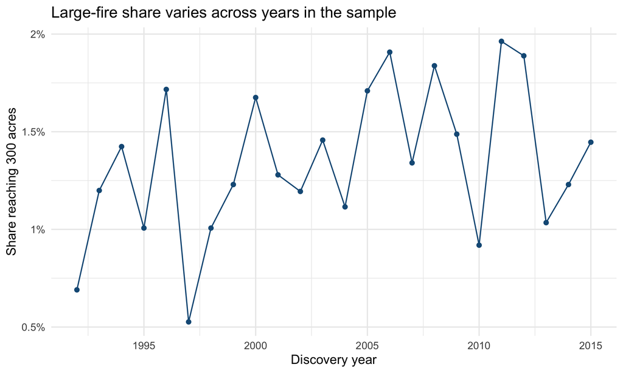

Large-fire proportions among sampled recorded events. These are not estimates of regional fire occurrence.

```r
ggplot(a$annual,aes(FIRE_YEAR,large)) + geom_line(color='#175a86') + geom_point(color='#175a86') +
 scale_y_continuous(labels=function(x) paste0(round(x*100,1),'%')) +
 labs(title='Large-fire share varies across years in the sample',x='Discovery year',y='Share reaching 300 acres')
```

This descriptive figure uses all years to describe the supplied data; no feature selection or model tuning uses the test-year outcomes. Calendar and location features follow the original seasonal/geographic hypothesis. The analysis is an exploratory portfolio revision, not a preregistered experiment.

# 4 Evaluation design

```r
z<-a$splits; z$prevalence<-pct(z$prevalence)
names(z)<-c('Partition','First year','Last year','Events','Large fires','Large-fire share')
knitr::kable(z,align=c('l',rep('r',5)))
```

| Partition | First year | Last year | Events | Large fires | Large-fire share |
| --- | --- | --- | --- | --- | --- |
| train | 1992 | 2008 | 71796 | 975 | 1.358% |
| calibration | 2009 | 2011 | 13258 | 195 | 1.471% |
| test | 2012 | 2015 | 14946 | 211 | 1.412% |

- **1992-2008:** fit all base models and the training-prevalence reference.
- **2009-2011:** fit the forest’s two-parameter logistic calibration only.
- **2012-2015:** evaluate fixed models and calibration without refitting.

Time partitions prevent future observations from entering the fitted models. They do not test transfer to unseen regions: locations can recur across years. The four annual test slices use the same fitted models and are not rolling retraining folds. Weather-driven and reporting dependencies can remain within and between years. No random event-level split or ordinary independent-row confidence interval is used to suggest more certainty than this design supports.

## 4.1 Models and available information

The same-feature comparison uses six inputs: sine and cosine of discovery month, centered discovery year, state/territory, latitude, and longitude. State is a categorical predictor in both models. Logistic regression uses additive effects and linear coordinate/year terms; the forest can learn nonlinearities and interactions from the same inputs. These structural differences remain even with matched features. A smaller seasonal logistic model illustrates the effect of adding geography, but is not the fair algorithm comparison.

The forest uses 300 trees, `mtry=3`, minimum terminal node size 50, and seed 141. These fixed settings bound complexity without searching test results. Training uses every training event at its natural class frequency: no downsampling or class weighting changes the probability target. Models are not refit after calibration, so that the calibrator remains attached to the model that generated its inputs. A limited fixed specification is not an exhaustive algorithm comparison.

A logistic calibrator maps the forest’s log-odds to probabilities using only the calibration years. Forest probabilities are clipped to [0.000001, 0.999999] for logarithms. The same clipping is used when computing log loss for every model. The calibration slope is positive, so ranking metrics are unchanged.

Final size, size class, containment dates/times, causes, reporting IDs, names, and reporting-system fields never enter the predictors. Final size supplies the label only. Month, location, and state are plausibly available at discovery, but the file contains final compiled values rather than time-stamped snapshots. This is not proof that these exact recorded inputs were available to an incident team.

# 5 Test results

```r
z<-a$scores
z$Model<-unname(model_labels[z$Model])
z[-1]<-lapply(z[-1],function(x) sprintf('%.5f',x))
names(z)<-c('Model','ROC-AUC ↑','PR area / AP ↑','Brier ↓','Log loss ↓')
knitr::kable(z,row.names=FALSE)
```

| Model | ROC-AUC ↑ | PR area / AP ↑ | Brier ↓ | Log loss ↓ |
| --- | --- | --- | --- | --- |
| Prevalence reference | 0.50000 | 0.01412 | 0.01392 | 0.07417 |
| Seasonal logistic | 0.65364 | 0.02263 | 0.01391 | 0.07381 |
| Logistic regression | 0.77089 | 0.04945 | 0.01406 | 0.07056 |
| Random Forest | 0.72572 | 0.09897 | 0.01352 | 0.10432 |
| Calibrated forest | 0.72572 | 0.09897 | 0.01369 | 0.06901 |

**PR area is average precision (AP):** precision integrated as a step function over recall, grouping tied scores. It is not trapezoidal interpolation of a PR curve. The constant-score AP reference equals test prevalence (0.014). ROC-AUC uses larger scores to mean more likely large fires, with half credit for ties. Brier score is mean squared probability error; log loss penalizes confident wrong predictions. Both use the original test prevalence.

Logistic regression reaches **0.771 ROC-AUC**, compared with **0.726** for the forest. The forest’s **0.099 AP** exceeds logistic regression’s **0.049**. These metrics emphasize different parts of the score distribution: ROC-AUC summarizes positive-negative ordering, while AP emphasizes precision as positives are retrieved. A higher AP does not mean high precision at every threshold.

The raw forest has the lowest Brier score but the worst log loss in this table. Calibration improves its log loss, while its Brier score becomes slightly worse. The additive logistic model’s Brier score is slightly worse than the constant reference despite its stronger ranking. This is why discrimination alone cannot establish probability quality. These are descriptive comparisons, without a formal claim of statistical superiority.

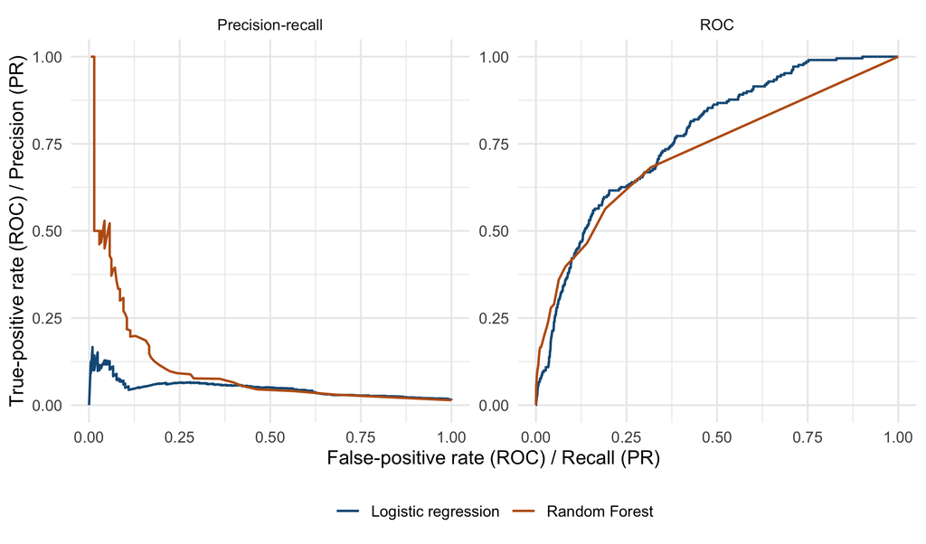

Test ROC and precision-recall curves. The forest and its calibrated version have identical ranking curves.

```r
roc_data<-do.call(rbind,lapply(c('Logistic','Random_forest'),function(m){
 s<-p[[m]];o<-order(s,decreasing=TRUE);y<-p$y[o];s<-s[o]
 ends<-c(which(diff(s)!=0),length(s));tp<-cumsum(y)[ends];fp<-ends-tp
 data.frame(x=c(0,fp/sum(y==0)),y=c(0,tp/sum(y)),Model=m,Panel='ROC')
}))
pr_data<-do.call(rbind,lapply(c('Logistic','Random_forest'),function(m){
 z<-pr_curve(p$y,p[[m]]);data.frame(x=z$recall,y=z$precision,Model=m,Panel='Precision-recall')
}))
ggplot(rbind(roc_data,pr_data),aes(x,y,color=Model)) + geom_path(linewidth=.7) +
 facet_wrap(~Panel,scales='free') + scale_color_manual(values=colors,labels=model_labels) +
 labs(x='False-positive rate (ROC) / Recall (PR)',y='True-positive rate (ROC) / Precision (PR)',color=NULL) +
 theme(legend.position='bottom')
```

## 5.1 Calibration on later events

The reliability plot groups test probabilities into fixed intervals. Each point compares the group’s mean probability with its observed large-fire share. Point size shows the event count; tail bins may contain few events. The diagonal denotes agreement, not a confidence bound. Binning can hide individual errors and does not validate probabilities outside the historical sample.

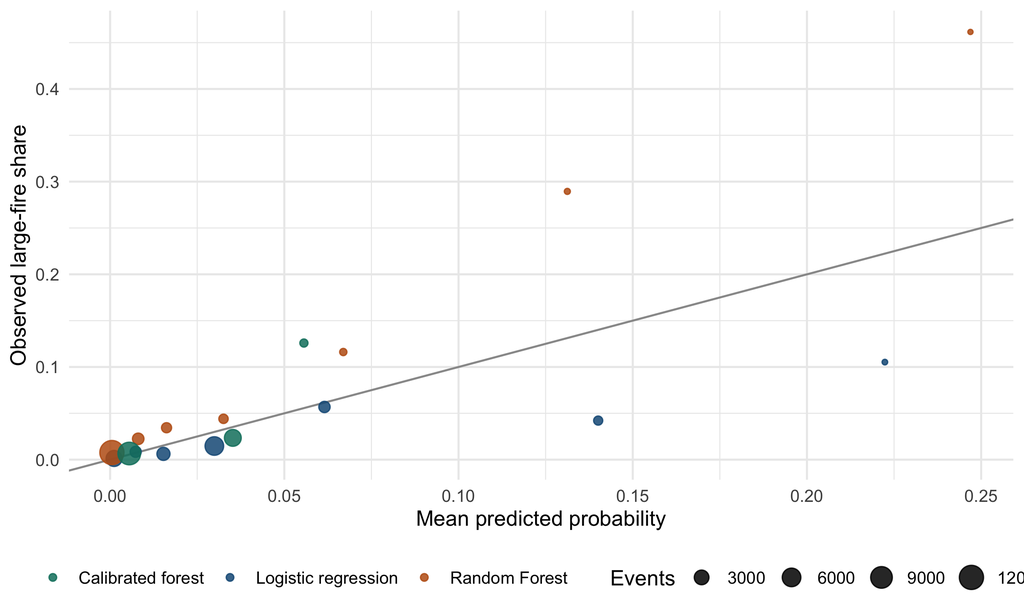

Binned test reliability; all nonempty bins are shown. Wide variation in bin counts limits comparisons in the tails.

```r
rel<-do.call(rbind,lapply(c('Logistic','Random_forest','Calibrated_forest'),function(m){
 z<-data.frame(pred=p[[m]],actual=p$y)
 z$bin<-cut(z$pred,c(-Inf,.005,.01,.02,.05,.1,.2,Inf))
 do.call(rbind,lapply(split(z,z$bin,drop=TRUE),function(b)data.frame(Model=m,
 pred=mean(b$pred),observed=mean(b$actual),n=nrow(b))))
}))
ggplot(rel,aes(pred,observed,color=Model,size=n)) + geom_abline(slope=1,intercept=0,color='grey60') +
 geom_point(alpha=.85) + scale_color_manual(values=colors,labels=model_labels) +
 labs(x='Mean predicted probability',y='Observed large-fire share',size='Events',color=NULL) +
 theme(legend.position='bottom')
```

## 5.2 Stability across test years

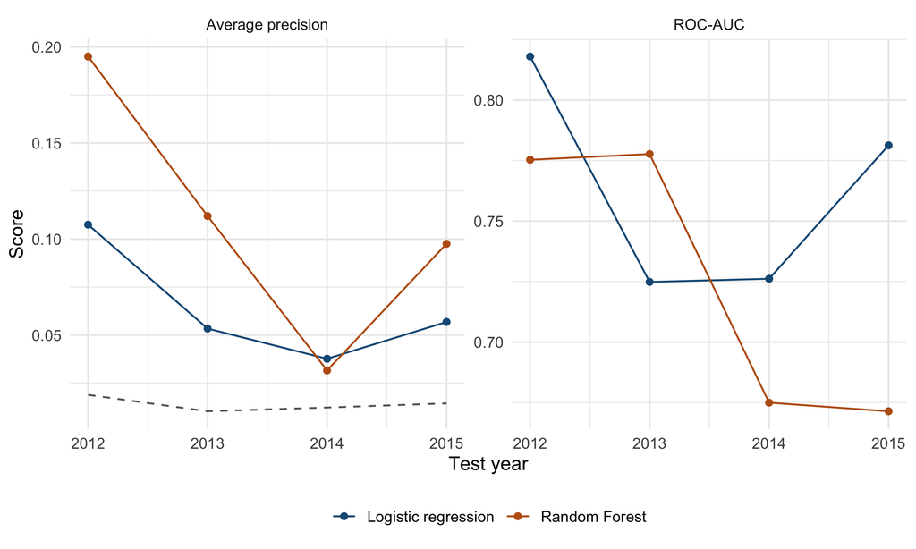

Annual performance of the same fixed models. The dashed PR reference is each year’s observed prevalence.

```r
z<-a$yearly[a$yearly$Model %in% c('Logistic','Random_forest'),]
long<-rbind(data.frame(year=z$year,Model=z$Model,value=z$ROC_AUC,Metric='ROC-AUC'),
 data.frame(year=z$year,Model=z$Model,value=z$PR_AUC_AP,Metric='Average precision'))
ref<-unique(a$yearly[c('year','prevalence')]);ref$Metric<-'Average precision'
ggplot(long,aes(year,value,color=Model)) + geom_line() + geom_point() +
 geom_line(data=ref,aes(year,prevalence),inherit.aes=FALSE,linetype=2,color='grey40') +
 facet_wrap(~Metric,scales='free_y') + scale_color_manual(values=colors,labels=model_labels) +
 scale_x_continuous(breaks=2012:2015) + labs(x='Test year',y='Score',color=NULL) +
 theme(legend.position='bottom')
```

```r
z<-a$yearly[a$yearly$Model %in% c('Logistic','Random_forest'),c('year','n','positives','Model','ROC_AUC','PR_AUC_AP')]
z$Model<-unname(model_labels[z$Model])
knitr::kable(z,digits=3,row.names=FALSE)
```

| year | n | positives | Model | ROC_AUC | PR_AUC_AP |
| --- | --- | --- | --- | --- | --- |
| 2012 | 3865 | 73 | Logistic regression | 0.818 | 0.107 |
| 2012 | 3865 | 73 | Random Forest | 0.775 | 0.195 |
| 2013 | 3480 | 36 | Logistic regression | 0.725 | 0.053 |
| 2013 | 3480 | 36 | Random Forest | 0.778 | 0.112 |
| 2014 | 3660 | 45 | Logistic regression | 0.726 | 0.038 |
| 2014 | 3660 | 45 | Random Forest | 0.675 | 0.032 |
| 2015 | 3941 | 57 | Logistic regression | 0.781 | 0.057 |
| 2015 | 3941 | 57 | Random Forest | 0.671 | 0.098 |

There are only 211 positives across the whole test period. Annual estimates have fewer positives and should not be read as stable performance guarantees. No threshold is chosen on the test set, and no deployment decision is inferred from these scores. An operational threshold would require prospective validation and explicit costs for missed large fires and false alarms.

# 6 Limits and next steps

1. **Unknown selection:** the sample’s inclusion probabilities are unavailable. Neither prevalence nor calibrated probabilities can be generalized to all reported fires, much less all actual fires, without checking selection.
2. **Retrospective records:** final administrative records can differ from discovery-time information. Identifier uniqueness does not verify incident independence, location accuracy, or complete coverage.
3. **Historical and geographic scope:** test years end in 2015. Temporal testing in recurring locations does not establish current or new-region performance. Year extrapolation and changing reporting practices can degrade both models.
4. **Limited predictors:** location and calendar are coarse proxies. This study cannot identify causal drivers or effects of interventions. Adding weather or vegetation requires historical, discovery-time joins with leakage checks.
5. **Target scope:** final area is only one dimension of severity. This model neither forecasts ignition nor predicts losses, ecological harm, or resources.

The useful result is a reproducible comparison with a defensible label and visible tradeoffs. Further work should first verify the extract’s sampling process and record-time availability, then test a locked specification on newer data and spatial holdouts before considering operational use.

# 7 Reproduce and inspect

Restore the recorded dependency versions with `renv::restore()` first (see the repository README), then run from the repository root:

```bash
Rscript scripts/run_analysis.R
Rscript tests/test_analysis.R
Rscript scripts/render_report.R
```

The full run reads the bundled CSV, fits models, writes event-level test probabilities and metric tables, verifies them, and builds this PDF. The report source and modeling code are available in the repository. Rendering alone reads saved results and does not refit models. Seeds, parameters, package versions, input hashes, and raw results are committed. The GitHub workflow repeats the complete analysis and checks the committed metrics. See `results/session-info.txt` and `results/dependency-versions.csv` for the tested environment.